# Lab 06

## 4

#### Find the variance of the distributions you created in the question above.

#### What is the difference between the variance and the standard deviation?

```r
var(logSeq)
```

```
## [1] 9.851602e+16
```

```r
# sd(logSeq)^2 == var(logSeq)
sd(logSeq)^2
```

```
## [1] 9.851602e+16
```

```r
sd(logSeq)^2 == var(logSeq)
```

```
## [1] TRUE
```

## 5

#### Find the expected value of the exponential distribution using the dexp function and also find the expected value of 1000 random draws.

#### Why do you think there is a discrepancy between these two values?

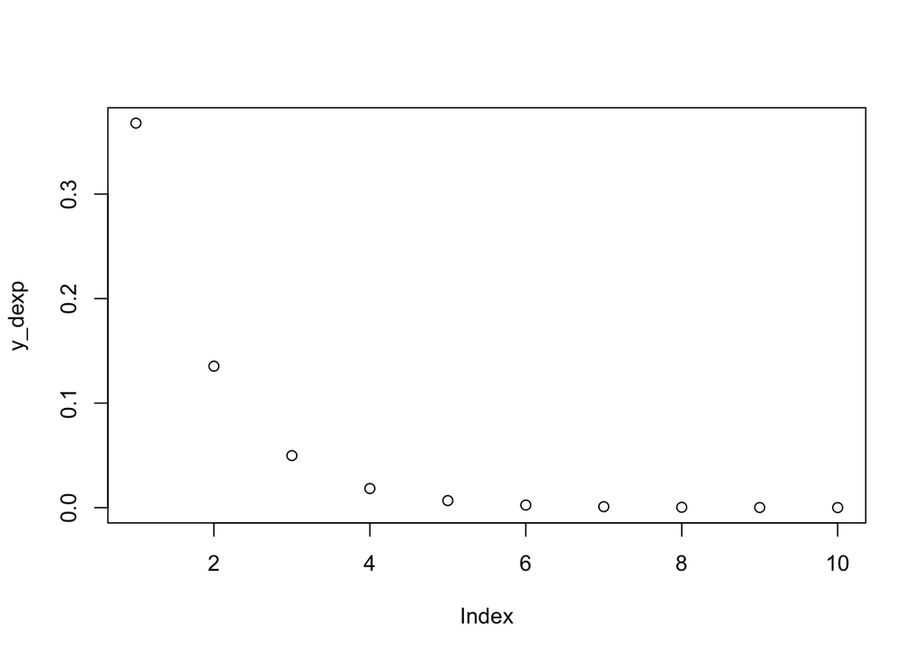

```r
y_dexp <- dexp(1:10)
plot(y_dexp)
```

```r
lower <- floor(qexp(0.001, rate=0.2))
upper <- ceiling(qexp(0.999, rate=0.2))
t <- seq(lower,upper,0.1)
dexp02 <- data.frame(T=t, Density=dexp(t, rate=0.2))

expVal_dexp <- mean(dexp02$Density)
expVal_dexp
```

```
## [1] 0.02875016
```

```r
random_draws <- c()
for(i in 1:1000){
  random_draws[i] <- sample(dexp02$Density,1)
}
expVal_1000randomDraws <- mean(random_draws)
expVal_1000randomDraws
```

```
## [1] 0.02955397
```

```r
# The difference of expVal_dexp and expVal_1000randomDraws is very small.
expVal_dexp - expVal_1000randomDraws
```

```
## [1] -0.0008038154
```

```r
# When we have random draws from the population, only when infinite draws can make make [the expected value of the random draws] the same as [the expected value of the distribution].
```

## 6

#### Why does the quantile function for the exponential distribution have an undefined expected value?

```r
q <- seq(0.001,0.999,0.001)
qexp02 <- data.frame(Q=q, Quantile=qexp(q, rate=0.2))
head(dexp02)
```

```
##     T   Density
## 1 0.0 0.2000000
## 2 0.1 0.1960397
## 3 0.2 0.1921579
## 4 0.3 0.1883529
## 5 0.4 0.1846233
## 6 0.5 0.1809675
```

```r
# The quantile function for the exponential distribution has an undefined expected value
# because the expected value for an absolutely continuous distribution is defined as ∫xf(x)dx where f is the density function and the integral is taken over the domain of f (which is −INF to INF).
# For a random variable X, if we take a draw from its distribution you know it will not be not likely be equal to the average. Therefore we are not "expecting" it to be some particular value. Thus, expected value is undefined.
```

## 7

#### What do we mean by saying that exponential distributions do not have a memory?

```r
# The exponential distribution is memoryless because the past has no bearing on its future behavior.
# Every instant is like the beginning of a new random period, which has the same distribution regardless of how much time has already elapsed.
# The exponential is the only memoryless continuous random variable.
```

## 8

#### Name a few examples of when to use the exponential distribution or when it comes up in nature.

```r
# The growth of the population is exponential, given infinite resources of energy and space.
# Microorganisms in culture
# Compound interest
```

## 9

#### Create 3 random number generators in R with different seeds and provide the first ten results from each.

```r
# 1st seed = 1
set.seed(1)
rnorm(10)
```

```
##  [1] -0.6264538  0.1836433 -0.8356286  1.5952808  0.3295078 -0.8204684
##  [7]  0.4874291  0.7383247  0.5757814 -0.3053884
```

```r
# 2nd seed = 5
set.seed(5)
rnorm(10)
```

```
##  [1] -0.84085548  1.38435934 -1.25549186  0.07014277  1.71144087 -0.60290798
##  [7] -0.47216639 -0.63537131 -0.28577363  0.13810822
```

```r
# 3rd seed = 15
set.seed(15)
rnorm(10)
```

```
##  [1]  0.2588229  1.8311207 -0.3396186  0.8971982  0.4880163 -1.2553858
##  [7]  0.0227882  1.0907732 -0.1321224 -1.0750013
```

## 10 BONUS

#### Prove how the exponential distribution is a special case of the gamma distribution?

## 11 BONUS

#### Demonstrate and prove (with a script and visual representations) of how the exponential distribution is memoryless.

```r
lambda <- 1/3
avrg <- 1/lambda
std.dv <- sqrt(1/lambda^2)

range <- seq(0, avrg+5*std.dv, 0.01)
y <- dexp(range, lambda)

x <- 4
# P(X>4)
1-pexp(x+0,lambda) / 1-pexp(0,lambda)
```

```
## [1] 0.2635971
```

```r
# P(X>6+4|X>6) == P(X>4)
(1-pexp(x+6,lambda)) / (1-pexp(6,lambda))
```

```
## [1] 0.2635971
```

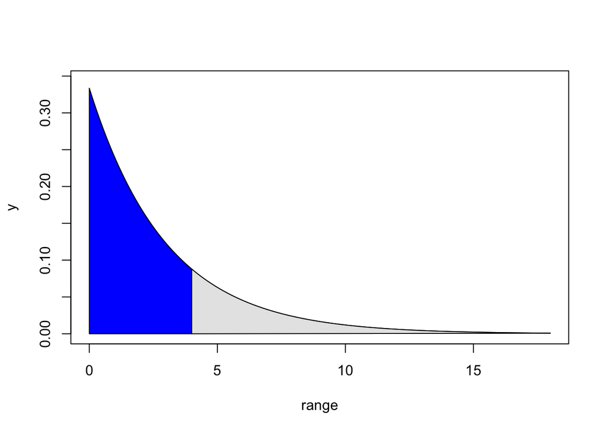

```r
# Draw the exponential distribution
# In the following two plots,
# the ratio of [ blue part / grey part ] should be the same value.

# P(X>4)
plot(range, y, type="l", ylim=c(0,max(y)+0.01))
cord.a <- c(0, seq(min(range),x,0.01),x)
cord.b <- c(0,dexp(seq(min(range),x,0.01),lambda),0)
polygon(cord.a,cord.b,col="blue")
cord.c <- c(x, seq(max(range),x,-0.01),x)
cord.d <- c(0,dexp(seq(max(range),x,-0.01),lambda),0)
polygon(cord.c,cord.d,col=grey(0.90))
```

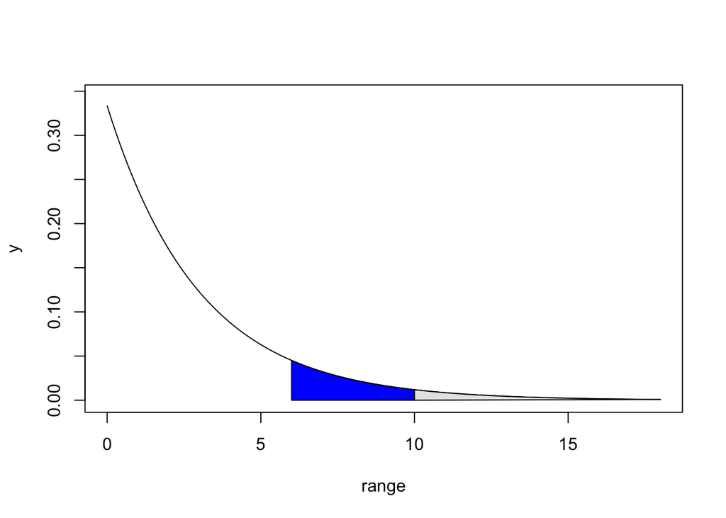

```r
# P(X>6+4|X>6) == P(X>4)
plot(range, y, type="l", ylim=c(0,max(y)+0.01))
cord.e <- c(6, seq(6,6+x,0.01),6+x)
cord.f <- c(0,dexp(seq(6,6+x,0.01),lambda),0)
polygon(cord.e,cord.f,col="blue")
cord.g <- c(6+x, seq(max(range),6+x,-0.01),6+x)
cord.h <- c(0,dexp(seq(max(range),6+x,-0.01),lambda),0)
polygon(cord.g,cord.h,col=grey(0.90))
```